# R-4

Regression Discontinuity Exploration

On August 16, 2018, the Bay Area Quality Management District approved a proposal by Phillips 66 to process an extra 61 million gallons of gas oil annually at its refinery in Rodeo (KQED). Local activists were concerned about the potential decrease in local air quality, but the air district board said the extra emissions would be in-line with regulations (Oakland Mag).

In order to get a specific picture of this scenario, imported PurpleAir sensor data for the city of Rodeo, CA.

The Rodeo 3 sensor was not in place until late 2018, so for the year 2018, I took Rodeo2 sensor data from July 2 to October 1 (90 days). For 2019, I took sensor data from Rodeo2 and Rodeo3 for that same time period.

I chose these time periods to avoid wildfires, such as the 2018 Camp Fire (November), and the recent string of wildfires begining in August of 2020. However, I was not able to avoid fires such as the Mendocino Complex Fire, which started in July 27, 2018 and raged for several months afterward, although smoke from that fire did not always reach the Bay Area.

```r
Rodeo_Full18 <- read.csv("/Users/natram3/Desktop/Rodeo2_Full18.csv", header = TRUE)

Rodeo_Fall18 <- read.csv("/Users/natram3/Desktop/Rodeo2_Fall18.csv", header = TRUE)

Rodeo_Summer18 <- read.csv("/Users/natram3/Desktop/Rodeo2_Summer18.csv", header = TRUE)

Rodeo3_Full19 <- read.csv("/Users/natram3/Desktop/Rodeo3_Full19.csv", header = TRUE)

Rodeo3_Fall19 <- read.csv("/Users/natram3/Desktop/Rodeo3_Fall19.csv", header = TRUE)

Rodeo3_Summer19 <- read.csv("/Users/natram3/Desktop/Rodeo3_Summer19.csv", header = TRUE)

Rodeo2_Full19 <- read.csv("/Users/natram3/Desktop/Rodeo2_Full19.csv", header = TRUE)

Rodeo2_Fall19 <- read.csv("/Users/natram3/Desktop/Rodeo2_Fall19.csv", header = TRUE)

Rodeo2_Summer19 <- read.csv("/Users/natram3/Desktop/Rodeo2_Summer19.csv", header = TRUE)
```

I reformatted the date columns, $created_at, to be class “Date”. I also renamed the PM data columns for the ease of calling these columns in the plotting section below.

```r
Rodeo_Full18$created_at <- Rodeo_Full18$created_at %>% as.Date(format = "%Y-%m-%d")

Rodeo_Full18 <- rename(Rodeo_Full18, Date = created_at,
                PM1.0 = PM1.0_CF1_ug.m3,
                PM2.5 = PM2.5_CF1_ug.m3,
                PM10.0 = PM10.0_CF1_ug.m3
                )

Rodeo_Fall18$created_at <- Rodeo_Fall18$created_at %>% as.Date(format = "%Y-%m-%d")

Rodeo_Fall18 <- rename(Rodeo_Fall18, Date = created_at,
                PM1.0 = PM1.0_CF1_ug.m3,
                PM2.5 = PM2.5_CF1_ug.m3,
                PM10.0 = PM10.0_CF1_ug.m3
                )

Rodeo_Summer18$created_at <- Rodeo_Summer18$created_at %>% as.Date(format = "%Y-%m-%d")

Rodeo_Summer18 <- rename(Rodeo_Summer18, Date = created_at,
                PM1.0 = PM1.0_CF1_ug.m3,
                PM2.5 = PM2.5_CF1_ug.m3,
                PM10.0 = PM10.0_CF1_ug.m3
                )

Rodeo2_Full19$created_at <- Rodeo2_Full19$created_at %>% as.Date(format = "%Y-%m-%d")

Rodeo2_Full19 <- rename(Rodeo2_Full19, Date = created_at,
                PM1.0 = PM1.0_CF1_ug.m3,
                PM2.5 = PM2.5_CF1_ug.m3,
                PM10.0 = PM10.0_CF1_ug.m3
                )

Rodeo2_Fall19$created_at <- Rodeo2_Fall19$created_at %>% as.Date(format = "%Y-%m-%d")

Rodeo2_Fall19 <- rename(Rodeo2_Fall19, Date = created_at,
                PM1.0 = PM1.0_CF1_ug.m3,
                PM2.5 = PM2.5_CF1_ug.m3,
                PM10.0 = PM10.0_CF1_ug.m3
                )

Rodeo2_Summer19$created_at <- Rodeo2_Summer19$created_at %>% as.Date(format = "%Y-%m-%d")

Rodeo2_Summer19 <- rename(Rodeo2_Summer19, Date = created_at,
                PM1.0 = PM1.0_CF1_ug.m3,
                PM2.5 = PM2.5_CF1_ug.m3,
                PM10.0 = PM10.0_CF1_ug.m3
                )

Rodeo3_Full19$created_at <- Rodeo3_Full19$created_at %>% as.Date(format = "%Y-%m-%d")

Rodeo3_Full19 <- rename(Rodeo3_Full19, Date = created_at,
                PM1.0 = PM1.0_CF1_ug.m3,
                PM2.5 = PM2.5_CF1_ug.m3,
                PM10.0 = PM10.0_CF1_ug.m3
                )

Rodeo3_Fall19$created_at <- Rodeo3_Fall19$created_at %>% as.Date(format = "%Y-%m-%d")

Rodeo3_Fall19 <- rename(Rodeo3_Fall19, Date = created_at,
                PM1.0 = PM1.0_CF1_ug.m3,
                PM2.5 = PM2.5_CF1_ug.m3,
                PM10.0 = PM10.0_CF1_ug.m3
                )

Rodeo3_Summer19$created_at <- Rodeo3_Summer19$created_at %>% as.Date(format = "%Y-%m-%d")

Rodeo3_Summer19 <- rename(Rodeo3_Summer19, Date = created_at,
                PM1.0 = PM1.0_CF1_ug.m3,
                PM2.5 = PM2.5_CF1_ug.m3,
                PM10.0 = PM10.0_CF1_ug.m3
                )
```

Here I plot the Rodeo2 sensor data for 2018, for the whole time period, then 45 days before the permitting event (July 2 - Aug 16), and 45 days after (Aug 17 - Oct 1).

For the overall time period, there appears to be a slight upwards trend; however, dividing the time period reveals that the upward trend is mostly due to the summer period before Aug 16, with a downward trend occurring from Aug 17 to Oct 1. While we have a cluster of 5 days seeing PM2.5 levels greater than 35, most other days have PM2.5 levels below 20.

This suggests that the permitting event may have not had a significant event on local air quality as the air district board suggested, but I will look at 2019 data for the same time period. (PM1.0 and PM10.0 show similar trends, so I do not show them to avoid redundancy).

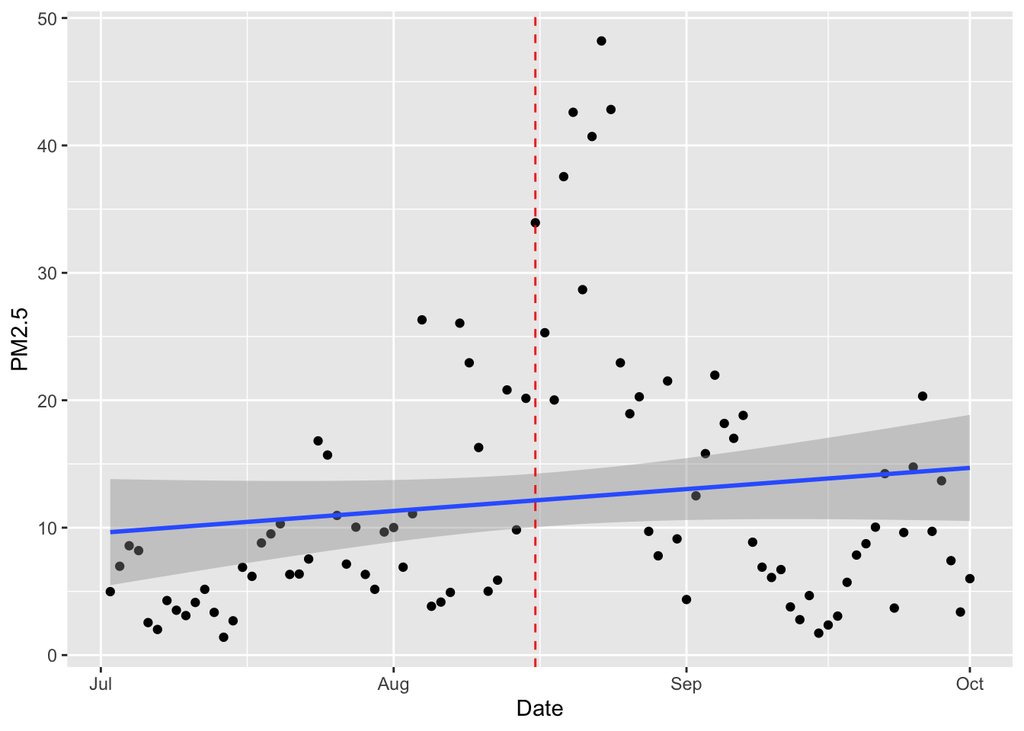

```r
ggplot(
  data = Rodeo_Full18,
  aes(
    x=Date,
    y=PM2.5
  )
  ) + geom_point() + geom_smooth(method =lm) +
     geom_vline(xintercept=as.numeric(Rodeo_Full18$Date[46]),
                linetype=2, colour="red")
```

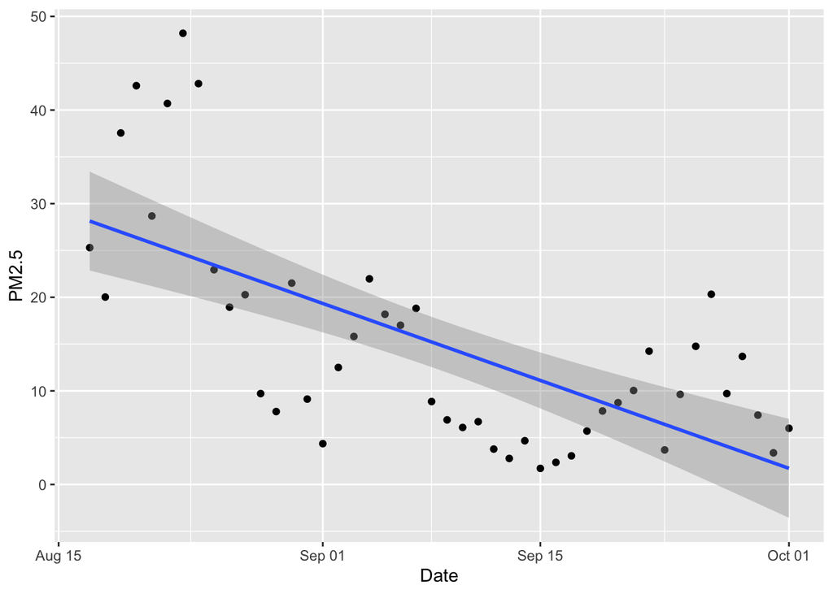

```r
ggplot(
  data = Rodeo_Fall18,
  aes(
    x=Date,
    y=PM2.5
  )
  ) + geom_point() + geom_smooth(method =lm)
```

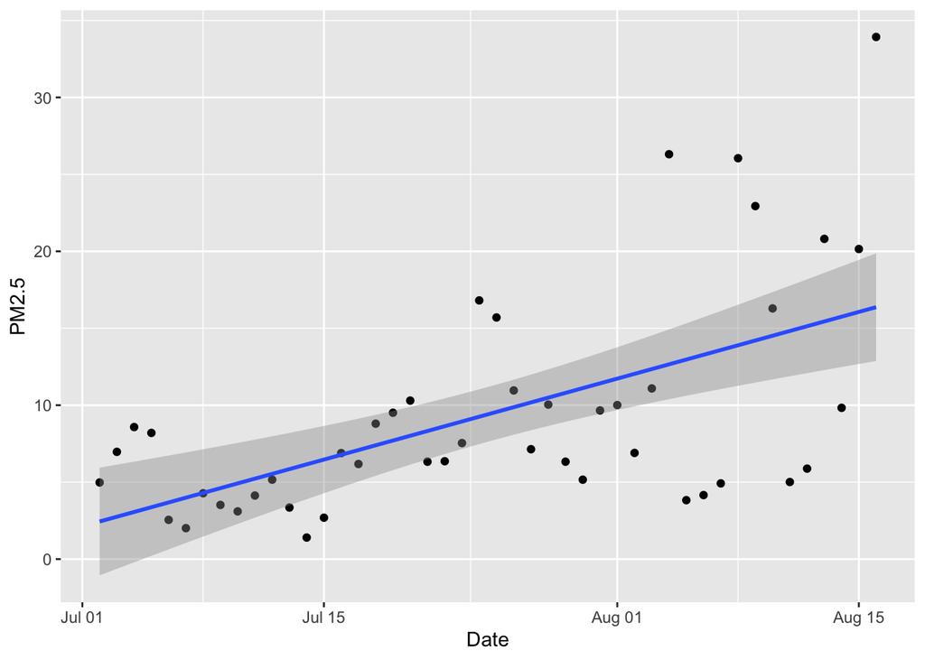

```r
ggplot(
  data = Rodeo_Summer18,
  aes(
    x=Date,
    y=PM2.5
  )
  ) + geom_point() + geom_smooth(method =lm)
```

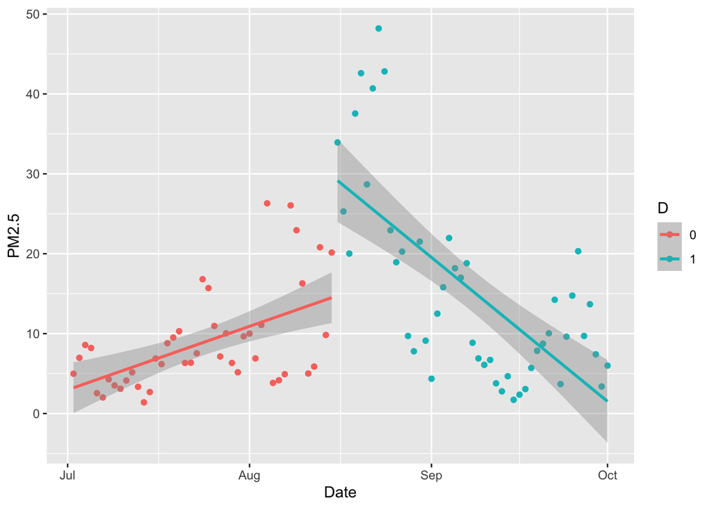

```r
rd <- Rodeo_Full18 %>%
  mutate(D = ifelse(Date >= '2018-08-16', 1, 0)) %$%
  lm(PM2.5 ~ D * I(Date - 46)) %>%
  summary()

rdplot <- Rodeo_Full18 %>%
  select(Date, PM2.5) %>%
  mutate(D = as.factor(ifelse(Date >= '2018-08-16', 1, 0))) %>%
  ggplot(aes(x = Date, y = PM2.5, color = D)) +
  geom_point() +
  geom_smooth(method = "lm")

rdplot
```

Unlike the 2018 data, this plot of 2019 data yields a slight downward trend across the time period (July 2 - Oct 1).

Similar to 2018, these data sets also have a slight upward trend from July 2 - Aug 16, and a slight downward trend from Aug 17 to Oct 1.

These trends are much less pronounced than the trends from 2018, especially after August 16. Given the variability of wildfire smoke, and without much data from the Philips 66 refinery regarding their emissions patterns, it’s not possible to draw any conclusions about the effect of their approved proprosal on local PM2.5 concentrations, let alone air quality concerns.

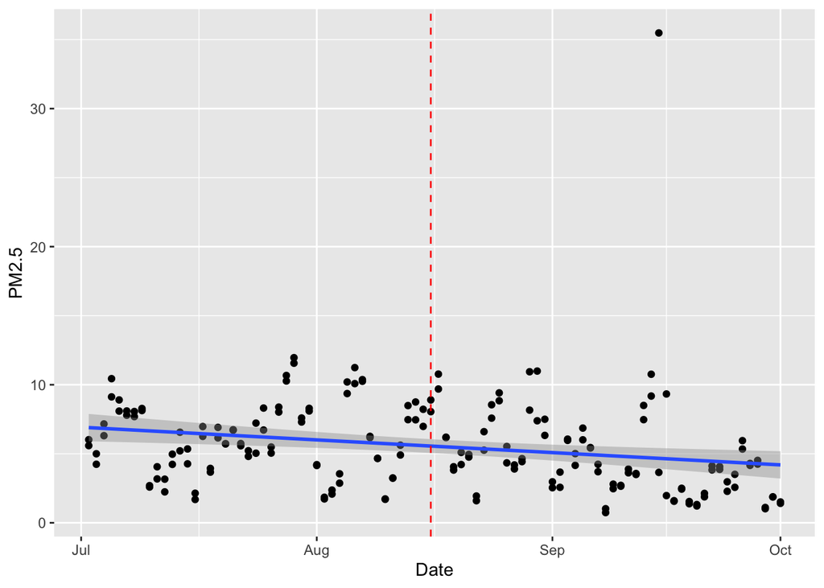

```r
Rodeo_Full19 <- rbind(Rodeo2_Full19, Rodeo3_Full19)
Rodeo_Fall19 <- rbind(Rodeo2_Fall19, Rodeo3_Fall19)
Rodeo_Summer19 <- rbind(Rodeo2_Summer19, Rodeo3_Summer19)

ggplot(
  data = Rodeo_Full19,
  aes(
    x=Date,
    y=PM2.5
  )
  ) + geom_point() + geom_smooth(method =lm) +
     geom_vline(xintercept=as.numeric(Rodeo_Full19$Date[46]),
                linetype=2, colour="red")
```

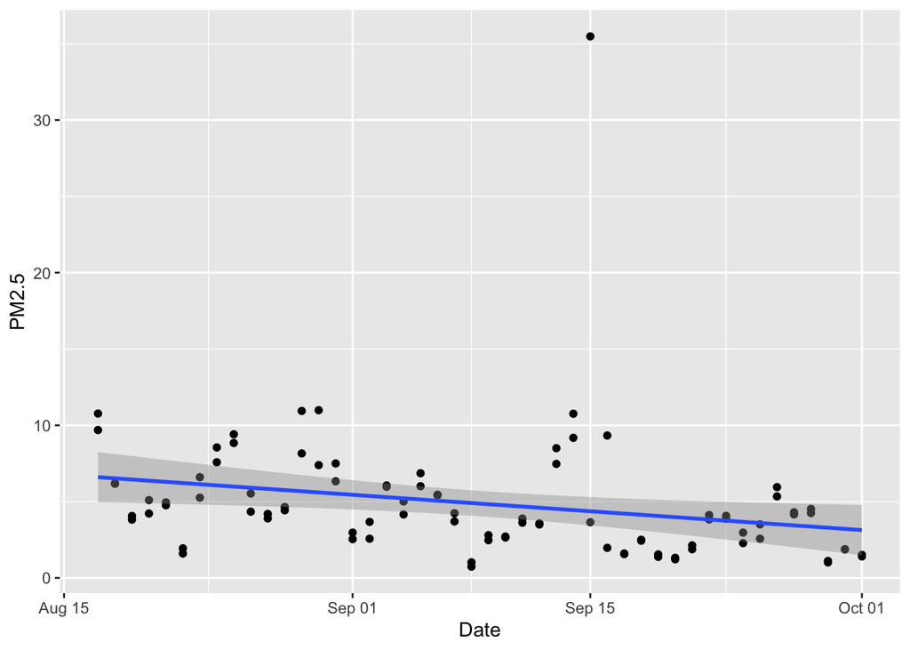

```r
ggplot(
  data = Rodeo_Fall19,
  aes(
    x=Date,
    y=PM2.5
  )
  ) + geom_point() + geom_smooth(method =lm)
```

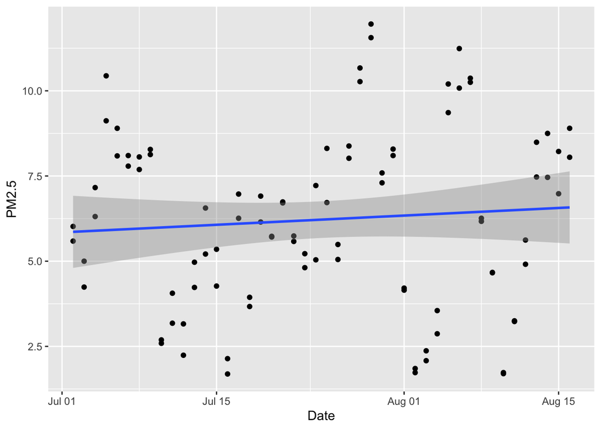

```r
ggplot(
  data = Rodeo_Summer19,
  aes(
    x=Date,
    y=PM2.5
  )
  ) + geom_point() + geom_smooth(method =lm)
```

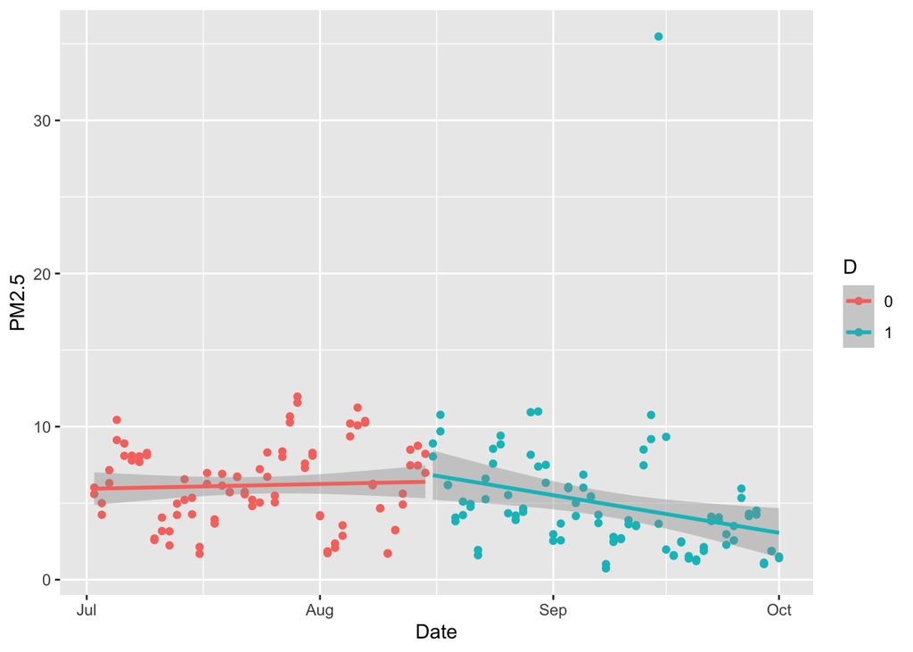

```r
rd19 <- Rodeo_Full19 %>%
  mutate(D = ifelse(Date >= '2019-08-16', 1, 0)) %$%
  lm(PM2.5 ~ D * I(Date - 46)) %>%
  summary()

rd19plot <- Rodeo_Full19 %>%
  select(Date, PM2.5) %>%
  mutate(D = as.factor(ifelse(Date >= '2019-08-16', 1, 0))) %>%
  ggplot(aes(x = Date, y = PM2.5, color = D)) +
  geom_point() +
  geom_smooth(method = "lm")

rd19plot
```

Works Cited:

KQED: https://www.kqed.org/news/11687389/air-district-oks-expansion-of-crude-oil-processing-at-phillips-66-refinery-in-rodeo

Oakland Mag: https://www.oaklandmagazine.com/November-2018/Delays-by-Air-Pollution-Regulators-Could-Cost-Lives/?action=logout

Guidance on Regression Discontinuity Graphing: https://bookdown.org/carillitony/bailey/chp11.html